# Batch correction

Christoph Hafemeister

2020-12-15

In this vignette we show how the regression model in the variance stabilizing transformation can also be used to mitigate batch effects. We use data from [Shekhar et al., Cell 2016](https://www.ncbi.nlm.nih.gov/pubmed/27565351) to demonstrate the functionality. The original analysis and data are available [here](https://github.com/broadinstitute/BipolarCell2016).

We first load the data and transform without using the batch information.

```r
# load data and cluster identities, and calculate some cell attributes
cm <- readRDS(file = "~/Projects/data/BipolarCell2016_GSE81904_sparse_matrix.Rds")
cell_attr <- read.table(file = "~/Projects/data/BipolarCell2016_GSE81904_ClustAssignFile.txt",
    header = TRUE, stringsAsFactors = FALSE, row.names = 1)
cell_attr <- cell_attr[colnames(cm), ]
cell_attr$CLUSTER <- factor(cell_attr$CLUSTER)
cell_attr$replicate <- as.integer(sapply(strsplit(rownames(cell_attr), "_"), function(x) gsub("Bipolar",
    "", x[1])))
cell_attr$batch <- factor(as.integer(cell_attr$replicate %in% c(5, 6)) + 1)
cell_attr$gene <- Matrix::colSums(cm > 0)
cell_attr$umi <- as.integer(Matrix::colSums(cm))
cell_attr$log_umi <- log10(cell_attr$umi)
cell_attr$umi_per_gene <- cell_attr$umi/cell_attr$gene
cell_attr$log_umi_per_gene <- log10(cell_attr$umi_per_gene)

# remove 50 weird 'cells'
weird <- cell_attr$log_umi_per_gene < 0.05 | cell_attr$log_umi_per_gene > 0.35
cm <- cm[, !weird]
cell_attr <- cell_attr[!weird, ]

# remove genes as in the paper; goes from 24904 down to 13181
bad_genes <- Matrix::rowSums(cm > 0) < 30 | Matrix::rowSums(cm) < 60
cm <- cm[!bad_genes, ]

# use fewer cells to speed up vignette compilation
set.seed(42)
keep <- sample(1:ncol(cm), 10000)
cm <- cm[, keep]
cell_attr <- cell_attr[keep, ]

# apply vst
set.seed(42)
vst_out <- vst(cm, cell_attr = cell_attr, latent_var = "log_umi_per_gene", verbosity = 1)
```

```
#> Variance stabilizing transformation of count matrix of size 13181 by 10000
#> Model formula is y ~ log_umi_per_gene
#> Get Negative Binomial regression parameters per gene
#> Using 2000 genes, 10000 cells
#> Found 12 outliers - those will be ignored in fitting/regularization step
#> Second step: Get residuals using fitted parameters for 13181 genes
#> Wall clock passed: Time difference of 59.76002 secs
```

In order to get an overview of the data, we perform dimensionality reduction (PCA) and keep the top 35 dimensions. For 2D plotting, we run t-SNE and display the batch label and the original clustering.

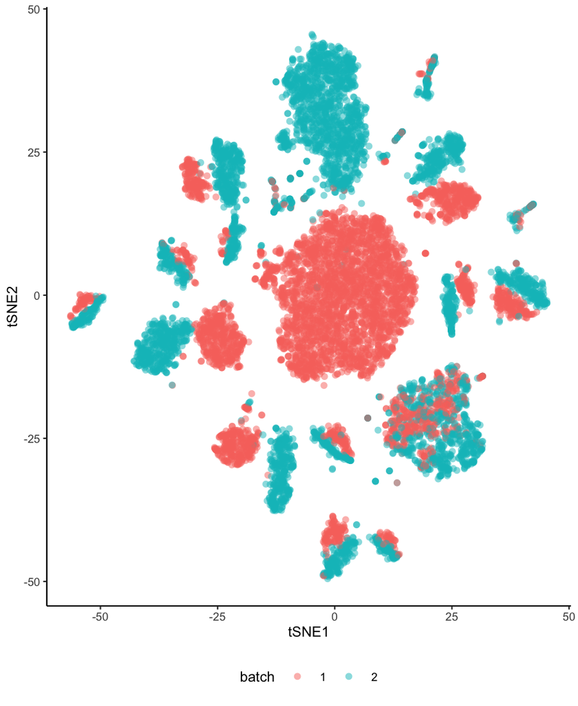

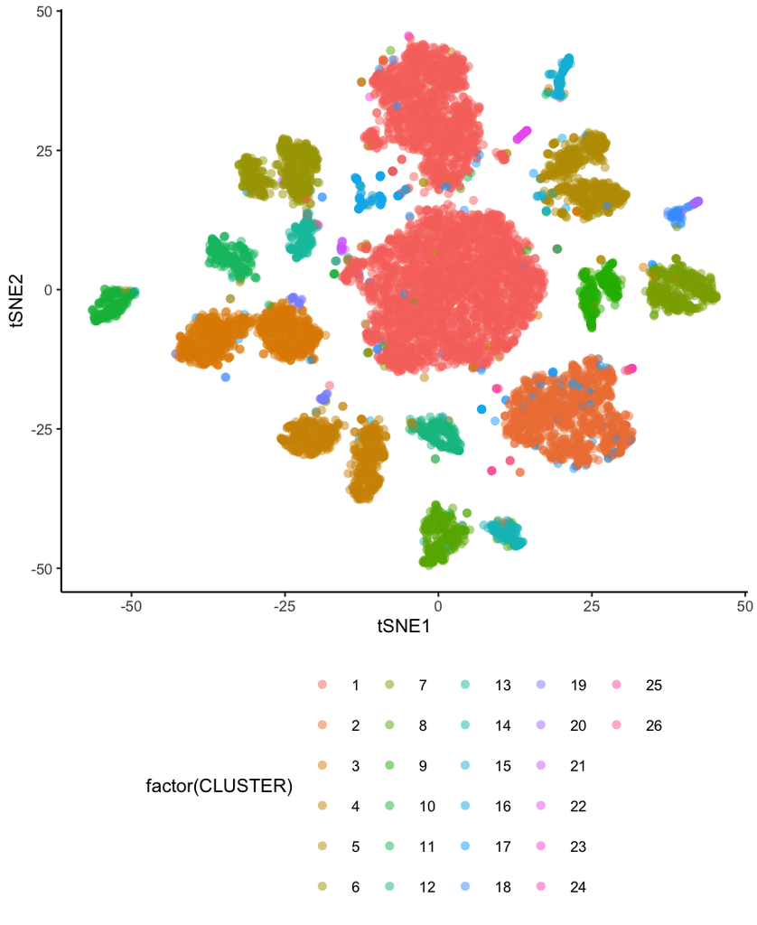

```r
pca <- irlba::prcomp_irlba(t(vst_out$y), n = 35)
tsne <- Rtsne::Rtsne(scale(pca$x), pca = FALSE)
cell_attr$tSNE1 <- tsne$Y[, 1]
cell_attr$tSNE2 <- tsne$Y[, 2]
ggplot(cell_attr, aes(tSNE1, tSNE2, color = batch)) + geom_point(alpha = 0.5, shape = 16) +
    theme(legend.position = "bottom")
ggplot(cell_attr, aes(tSNE1, tSNE2, color = factor(CLUSTER))) + geom_point(alpha = 0.5,
    shape = 16) + theme(legend.position = "bottom")
```

We can see a clear separation between batches, while the main source of variability in the data seems to come from the heterogeneity between cell types.

We will now repeat the analysis but this time specify a batch variable when calling `vst`. This changes the regression model specification, adding batch indicator variable and its interaction with the regression coefficients. This effectively fits the regression model per batch, but keeps a single theta variable (overdispersion parameter) per gene. Parameter regularization is performed per batch.

```r
set.seed(42)
vst_out2 <- vst(cm, cell_attr = cell_attr, latent_var = "log_umi_per_gene", batch_var = "batch",
    verbosity = 1)
```

```
#> Variance stabilizing transformation of count matrix of size 13181 by 10000
#> Model formula is y ~ (log_umi_per_gene) : batch + batch + 0
#> Get Negative Binomial regression parameters per gene
#> Using 2000 genes, 10000 cells
#> Found 30 outliers - those will be ignored in fitting/regularization step
#> Second step: Get residuals using fitted parameters for 13181 genes
#> Wall clock passed: Time difference of 1.036737 mins
```

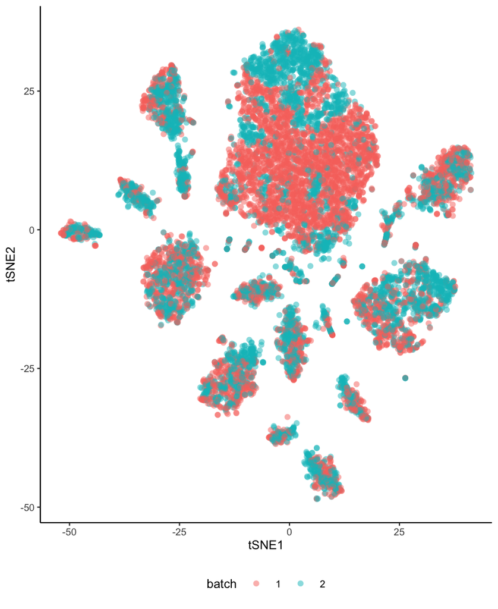

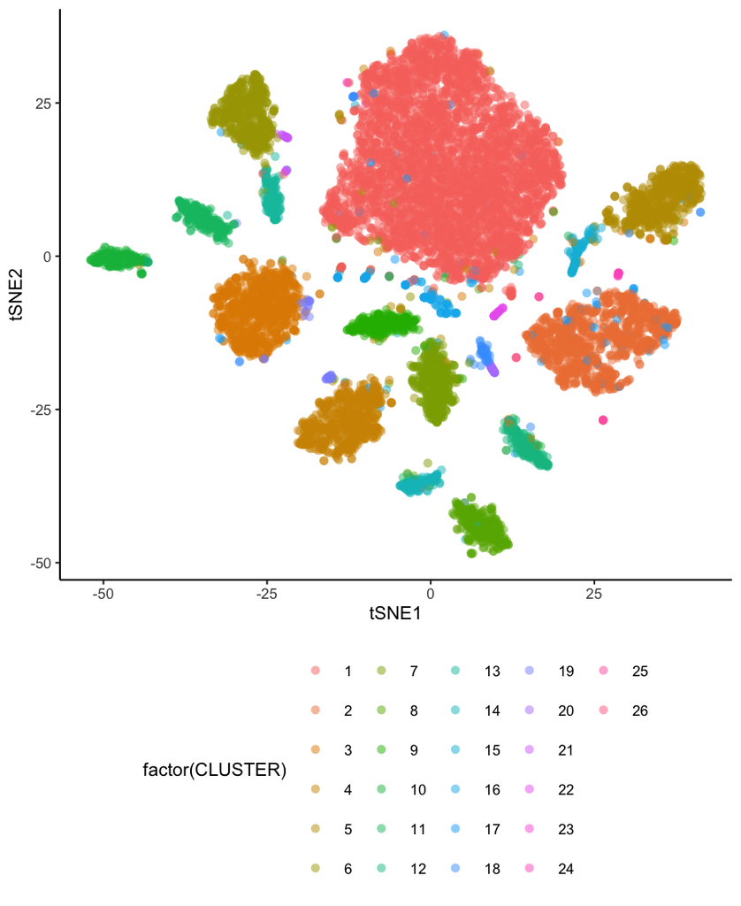

```r
# dimensionality reduction via PCA
pca2 <- irlba::prcomp_irlba(t(vst_out2$y), n = 35)

tsne2 <- Rtsne::Rtsne(scale(pca2$x), pca = FALSE)
cell_attr$tSNE1 <- tsne2$Y[, 1]
cell_attr$tSNE2 <- tsne2$Y[, 2]
ggplot(cell_attr, aes(tSNE1, tSNE2, color = batch)) + geom_point(alpha = 0.5, shape = 16) +
    theme(legend.position = "bottom")
ggplot(cell_attr, aes(tSNE1, tSNE2, color = factor(CLUSTER))) + geom_point(alpha = 0.5,
    shape = 16) + theme(legend.position = "bottom")
```

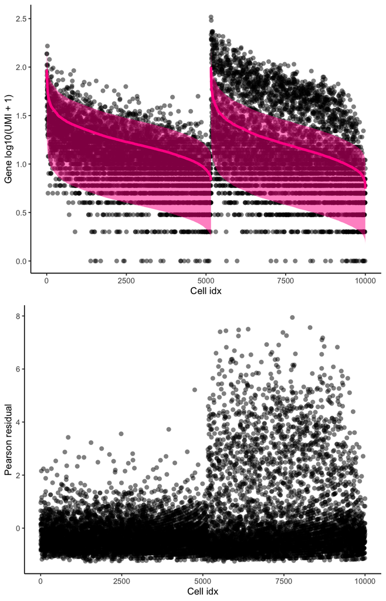

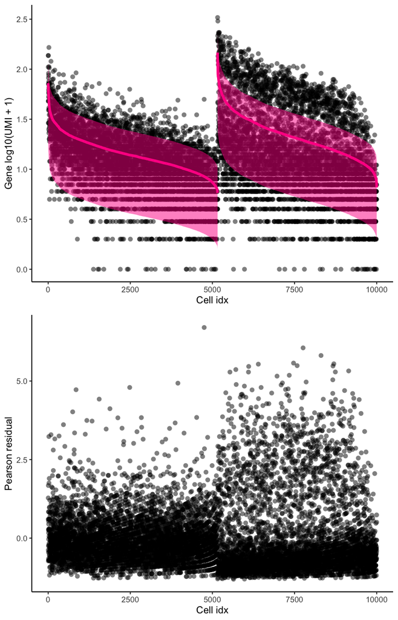

```r
# plot expression and model for one gene as example
cell_attr$idx <- NA
cell_attr$idx[order(cell_attr$batch, -cell_attr$log_umi_per_gene)] <- 1:ncol(cm)
goi <- "mt-Rnr2"
plot_model(vst_out, cm, goi, x_var = "idx", cell_attr = cell_attr, batches = cell_attr$batch,
    plot_residual = TRUE, show_density = FALSE)
plot_model(vst_out2, cm, goi, x_var = "idx", cell_attr = cell_attr, batches = cell_attr$batch,
    plot_residual = TRUE, show_density = FALSE)
```